# Final_Quabbin_Code

Abby Robinson

10/12/2022

#Temporal Dynamics of Predator Learning in a Batesian Mimicry Complex

##Packages

```r
library(curl)
```

```r
library(ggplot2)
library(lme4)
library(mvtnorm)
library(lattice)
library(multcomp)
library(emmeans)
library(ggpubr)
```

Load data

```r
d <- curl("https://raw.githubusercontent.com/butterfliesrcool/Quabbin_Data/main/Quabbin_TRIAL_SPECIES_data.csv")
data <- read.csv(d, header = TRUE, sep = ",")
head(data)
```

```
##   day site fac.no      species attacks time.delay trial
## 1   1    1      1 model_battus       0       four model
## 2   1    1      2 model_battus       0       four model
## 3   1    1      3 model_battus       0       four model
## 4   1    1      4 model_battus       0       four model
## 5   1    1      5 model_battus       0       four model
## 6   1    1      6 model_battus       0       four model
```

Subset out simultaneous trials (this experiment involved different samples sizes, so must be analyzed separately) & make sure “day” variable is factor, not integer

```r
temp.delay <- subset(data, trial %in% c("model", "mimic"), drop = FALSE)
class(temp.delay$day) #integer...
```

```
## [1] "integer"
```

```r
temp.delay$day <- as.factor(temp.delay$day)
class(temp.delay$day)
```

```
## [1] "factor"
```

subset out model and mimic trials for figures

```r
models <- subset(temp.delay, trial == "model", drop = FALSE)
mimics <- subset(temp.delay, trial == "mimic", drop = FALSE)
```

[1] Did birds learn to avoid Bitrex-treated facsimiles of Battus philenor (Pipevine Swallowtail)?

We expect to see high attack rates on Battus philenor initially because it is a large, conspicuous butterfly relative to the control, but attacks on this species should decline rapidly as avian predators learn to avoid it.

##Data Visualization

###summary of attack rates and figure for model trials

Summary of total attaks on Battus and Junonia (control) during model trials

```r
modeldays <- aggregate(x= models$attacks, by= list(models$day, models$species), FUN=sum)
modeldays
```

```
##   Group.1       Group.2  x
## 1       1  model_battus 20
## 2       2  model_battus  3
## 3       3  model_battus  3
## 4       4  model_battus  2
## 5       1 model_junonia 16
## 6       2 model_junonia 10
## 7       3 model_junonia  4
## 8       4 model_junonia  8
```

Calculate attack rates on Battus philenor

```r
###NOTE: presenting data in terms of "attack rates" instead of "number of attacks" seems to be the industry norm

b <- subset(models, species == "model_battus", drop = FALSE)
### there were 1,500 facsimilies of each species in the field for time-delayed trials one-four
b.days <- aggregate(x= b$attacks, by= list(b$day), FUN=sum)
percent <- (b.days$x/1500)*100
b.days$percent <- percent
b.days
```

```
##   Group.1  x   percent
## 1       1 20 1.3333333
## 2       2  3 0.2000000
## 3       3  3 0.2000000
## 4       4  2 0.1333333
```

Calculate attack rates on Junonia coenia

```r
j <- subset(models, species == "model_junonia", drop = FALSE)
j.days <- aggregate(x= j$attacks, by= list(j$day), FUN=sum)
percent <- (j.days$x/1500)*100
j.days$percent <- percent
j.days
```

```
##   Group.1  x   percent
## 1       1 16 1.0666667
## 2       2 10 0.6666667
## 3       3  4 0.2666667
## 4       4  8 0.5333333
```

Make barplots in ggplot

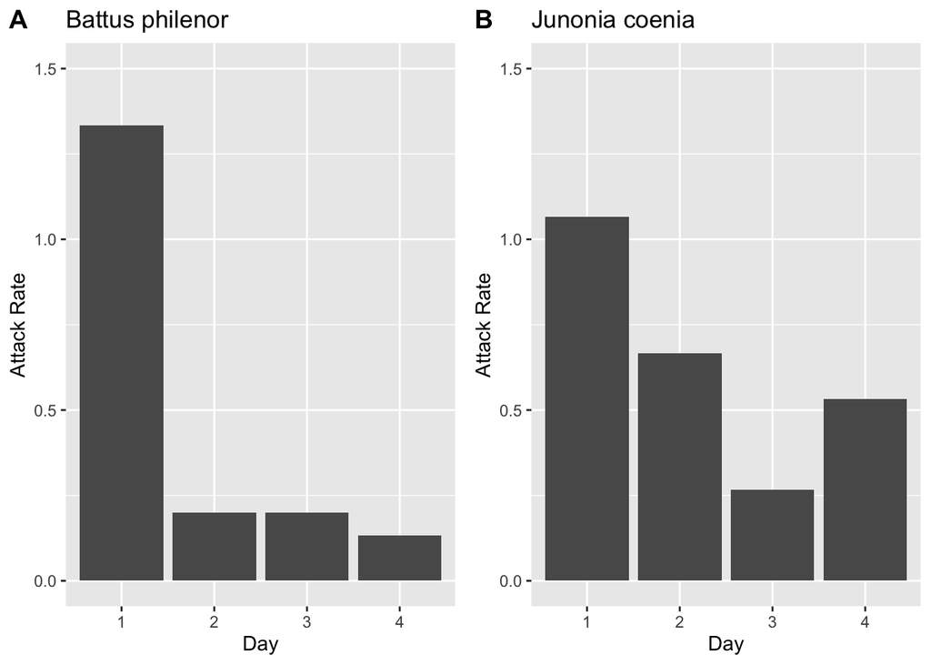

```r
battus <- ggplot(b.days, aes(x=Group.1, y=percent)) +  geom_bar(stat = "identity") + ylim(0,1.5)
battus <- battus  + xlab("Day") + ylab("Attack Rate") + ggtitle("Battus philenor")


junonia <- ggplot(j.days, aes(x=Group.1, y=percent)) +  geom_bar(stat = "identity") + ylim(0,1.5)
junonia <- junonia + xlab("Day") + ylab("Attack Rate") + ggtitle("Junonia coenia")


figure1 <- ggarrange(battus, junonia,
                    labels = c("A", "B"),
                    ncol = 2, nrow = 1)
figure1
```

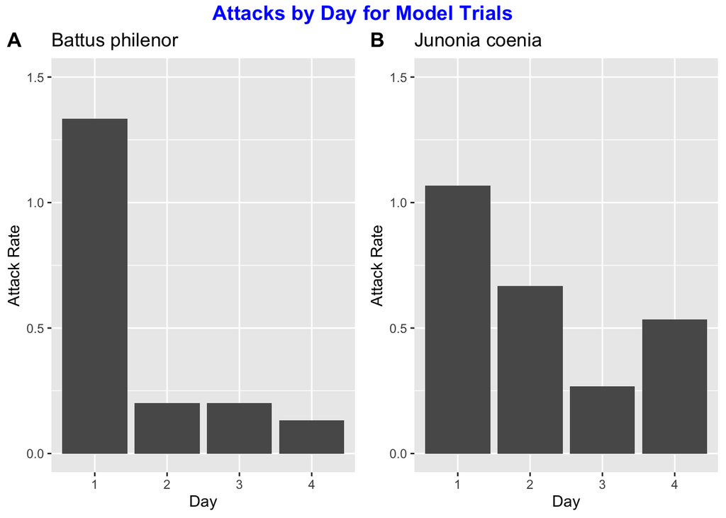

```r
figure1 <- annotate_figure(figure1, top = text_grob("Attacks by Day for Model Trials",
               color = "blue", face = "bold", size = 14))
figure1
```

###Same analysis but with mimic trials

```r
mimicdays <- aggregate(x= mimics$attacks, by= list(mimics$day, mimics$species), FUN=sum)
mimicdays
```

```
##   Group.1         Group.2  x
## 1       1   mimic_junonia 10
## 2       2   mimic_junonia  4
## 3       3   mimic_junonia  3
## 4       4   mimic_junonia  3
## 5       1 mimic_limenitis 12
## 6       2 mimic_limenitis  4
## 7       3 mimic_limenitis  7
## 8       4 mimic_limenitis  5
```

```r
l <- subset(mimics, species == "mimic_limenitis", drop = FALSE)
### there were 1,500 facsimilies of each species in the field for time-delayed trials one-four
l.days <- aggregate(x= l$attacks, by= list(l$day), FUN=sum)
percent <- (l.days$x/1500)*100
l.days$percent <- percent
l.days
```

```
##   Group.1  x   percent
## 1       1 12 0.8000000
## 2       2  4 0.2666667
## 3       3  7 0.4666667
## 4       4  5 0.3333333
```

Calculate attack rates on Junonia coenia

```r
lj <- subset(mimics, species == "mimic_junonia", drop = FALSE)
lj.days <- aggregate(x= lj$attacks, by= list(lj$day), FUN=sum)
percent <- (lj.days$x/1500)*100
lj.days$percent <- percent
lj.days
```

```
##   Group.1  x   percent
## 1       1 10 0.6666667
## 2       2  4 0.2666667
## 3       3  3 0.2000000
## 4       4  3 0.2000000
```

Make barplots in ggplot

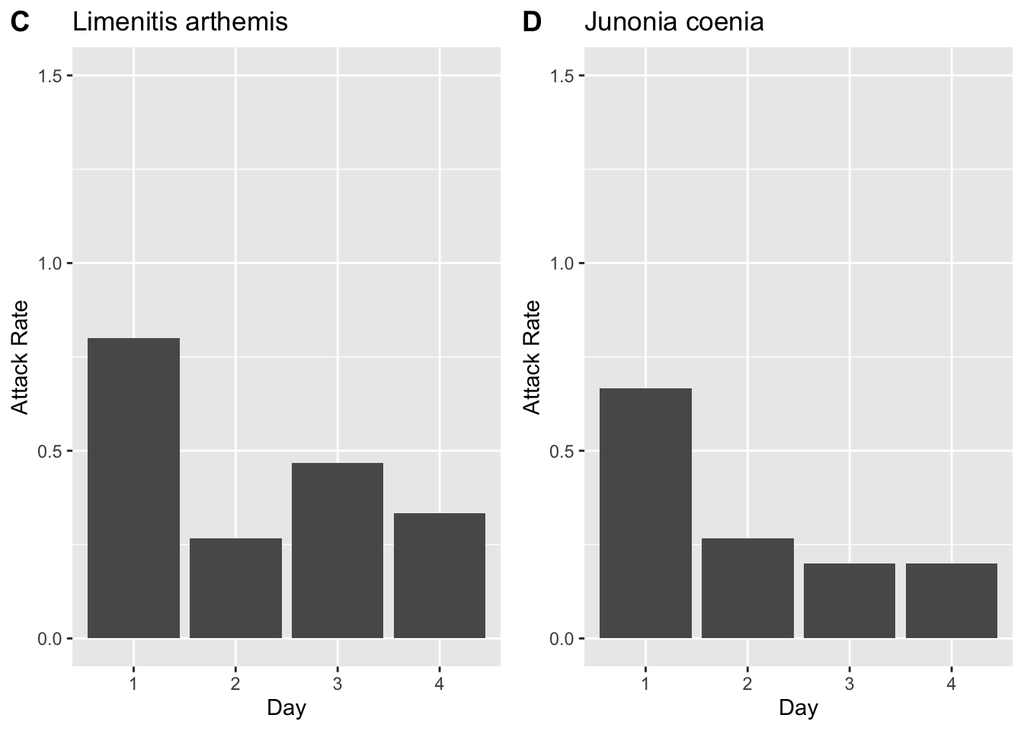

```r
limenitis <- ggplot(l.days, aes(x=Group.1, y=percent)) +  geom_bar(stat = "identity") + ylim(0,1.5)
limenitis <- limenitis  + xlab("Day") + ylab("Attack Rate") + ggtitle("Limenitis arthemis")


l.junonia <- ggplot(lj.days, aes(x=Group.1, y=percent)) +  geom_bar(stat = "identity") + ylim(0,1.5)
l.junonia <- l.junonia + xlab("Day") + ylab("Attack Rate") + ggtitle("Junonia coenia")


figure2 <- ggarrange(limenitis, l.junonia,
                    labels = c("C", "D"),
                    ncol = 2, nrow = 1)
figure2
```

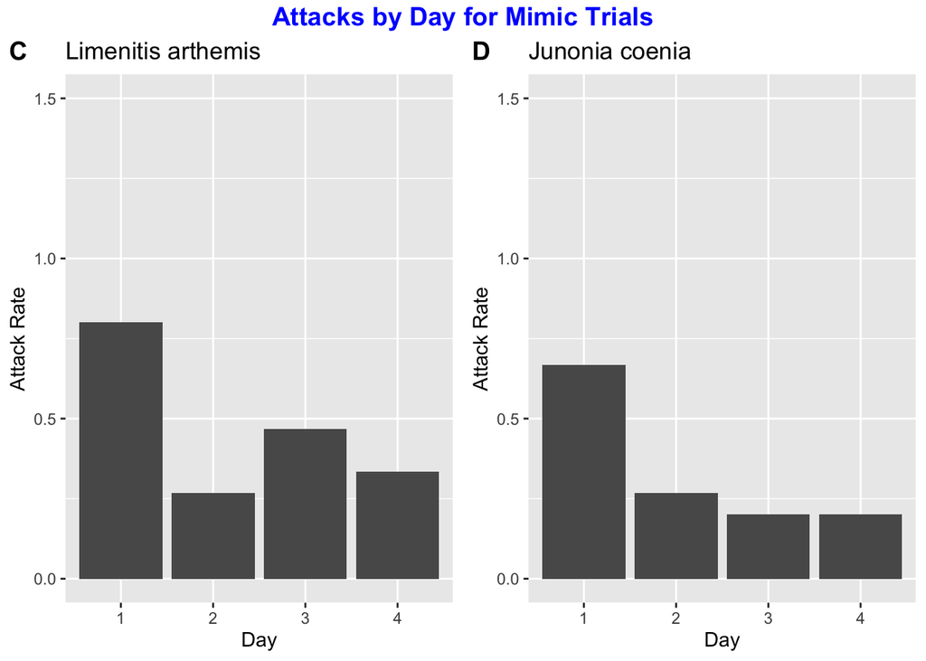

```r
figure2 <- annotate_figure(figure2, top = text_grob("Attacks by Day for Mimic Trials",
               color = "blue", face = "bold", size = 14))
figure2
```

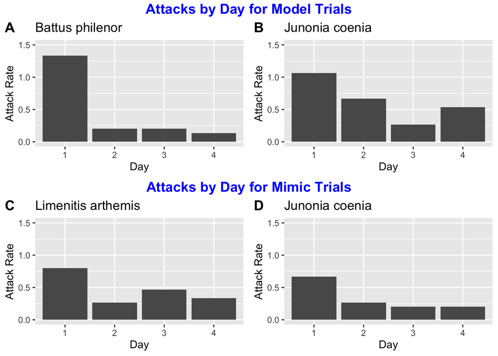

```r
figure3 <- ggarrange(figure1, figure2,
                    ncol = 1, nrow = 2)
figure3
```

I conducted generalized linear mixed model analyses with post-hoc tukey analyses for pairwise comparison of each day of the 4-day experiments for each species in the model and mimic “phases” of the experiment

Models analyzing all species data in model and mimic trials

```r
m1 <- glmer(attacks ~ species*day + (1|site/fac.no), data =  models, family = binomial)
emmeans(m1, pairwise ~ species*day)
```

```
## $emmeans
##  species       day emmean   SE  df asymp.LCL asymp.UCL
##  model_battus  1    -10.6 1.54 Inf     -13.6     -7.56
##  model_junonia 1    -10.9 1.55 Inf     -13.9     -7.86
##  model_battus  2    -12.7 1.63 Inf     -15.8     -9.47
##  model_junonia 2    -11.6 1.57 Inf     -14.6     -8.49
##  model_battus  3    -13.0 1.66 Inf     -16.3     -9.75
##  model_junonia 3    -12.6 1.62 Inf     -15.8     -9.42
##  model_battus  4    -13.8 1.78 Inf     -17.3    -10.31
##  model_junonia 4    -11.8 1.58 Inf     -14.9     -8.72
##
## Results are given on the logit (not the response) scale.
## Confidence level used: 0.95
##
## $contrasts
##  contrast                                estimate    SE  df z.ratio p.value
##  model_battus day1 - model_junonia day1    0.3134 0.404 Inf   0.777  0.9943
##  model_battus day1 - model_battus day2     2.0815 0.607 Inf   3.430  0.0140
##  model_battus day1 - model_junonia day2    0.9930 0.453 Inf   2.190  0.3574
##  model_battus day1 - model_battus day3     2.4242 0.684 Inf   3.546  0.0093
##  model_battus day1 - model_junonia day3    2.0211 0.595 Inf   3.395  0.0158
##  model_battus day1 - model_battus day4     3.2145 0.936 Inf   3.435  0.0138
##  model_battus day1 - model_junonia day4    1.2388 0.479 Inf   2.588  0.1600
##  model_junonia day1 - model_battus day2    1.7682 0.615 Inf   2.873  0.0782
##  model_junonia day1 - model_junonia day2   0.6797 0.465 Inf   1.461  0.8283
##  model_junonia day1 - model_battus day3    2.1108 0.691 Inf   3.054  0.0466
##  model_junonia day1 - model_junonia day3   1.7077 0.604 Inf   2.827  0.0883
##  model_junonia day1 - model_battus day4    2.9011 0.941 Inf   3.083  0.0429
##  model_junonia day1 - model_junonia day4   0.9254 0.490 Inf   1.890  0.5581
##  model_battus day2 - model_junonia day2   -1.0885 0.647 Inf  -1.683  0.6986
##  model_battus day2 - model_battus day3     0.3427 0.823 Inf   0.417  0.9999
##  model_battus day2 - model_junonia day3   -0.0605 0.751 Inf  -0.081  1.0000
##  model_battus day2 - model_battus day4     1.1330 1.041 Inf   1.088  0.9594
##  model_battus day2 - model_junonia day4   -0.8427 0.664 Inf  -1.269  0.9104
##  model_junonia day2 - model_battus day3    1.4312 0.719 Inf   1.990  0.4883
##  model_junonia day2 - model_junonia day3   1.0280 0.636 Inf   1.617  0.7404
##  model_junonia day2 - model_battus day4    2.2215 0.962 Inf   2.310  0.2878
##  model_junonia day2 - model_junonia day4   0.2458 0.529 Inf   0.464  0.9998
##  model_battus day3 - model_junonia day3   -0.4032 0.814 Inf  -0.495  0.9997
##  model_battus day3 - model_battus day4     0.7903 1.087 Inf   0.727  0.9962
##  model_battus day3 - model_junonia day4   -1.1854 0.735 Inf  -1.614  0.7421
##  model_junonia day3 - model_battus day4    1.1934 1.034 Inf   1.154  0.9447
##  model_junonia day3 - model_junonia day4  -0.7822 0.654 Inf  -1.197  0.9331
##  model_battus day4 - model_junonia day4   -1.9757 0.973 Inf  -2.030  0.4616
##
## Results are given on the log odds ratio (not the response) scale.
## P value adjustment: tukey method for comparing a family of 8 estimates
```

```r
m2 <- glmer(attacks ~ species*day + (1|site/fac.no), data =  mimics, family = binomial)
emmeans(m2, pairwise ~ species*day)
```

```
## $emmeans
##  species         day emmean    SE  df asymp.LCL asymp.UCL
##  mimic_junonia   1    -11.0 0.995 Inf     -12.9     -9.02
##  mimic_limenitis 1    -10.7 0.982 Inf     -12.7     -8.81
##  mimic_junonia   2    -12.1 1.080 Inf     -14.2     -9.95
##  mimic_limenitis 2    -12.1 1.079 Inf     -14.2     -9.94
##  mimic_junonia   3    -12.4 1.118 Inf     -14.6    -10.17
##  mimic_limenitis 3    -11.4 1.023 Inf     -13.4     -9.41
##  mimic_junonia   4    -12.4 1.119 Inf     -14.6    -10.18
##  mimic_limenitis 4    -11.8 1.054 Inf     -13.9     -9.74
##
## Results are given on the logit (not the response) scale.
## Confidence level used: 0.95
##
## $contrasts
##  contrast                                    estimate    SE  df z.ratio p.value
##  mimic_junonia day1 - mimic_limenitis day1   -0.23657 0.489 Inf  -0.484  0.9997
##  mimic_junonia day1 - mimic_junonia day2      1.09648 0.639 Inf   1.717  0.6760
##  mimic_junonia day1 - mimic_limenitis day2    1.08586 0.637 Inf   1.704  0.6846
##  mimic_junonia day1 - mimic_junonia day3      1.39357 0.697 Inf   1.998  0.4829
##  mimic_junonia day1 - mimic_limenitis day3    0.44591 0.547 Inf   0.816  0.9923
##  mimic_junonia day1 - mimic_junonia day4      1.40232 0.699 Inf   2.005  0.4783
##  mimic_junonia day1 - mimic_limenitis day4    0.83927 0.597 Inf   1.405  0.8551
##  mimic_limenitis day1 - mimic_junonia day2    1.33306 0.627 Inf   2.127  0.3970
##  mimic_limenitis day1 - mimic_limenitis day2  1.32243 0.624 Inf   2.118  0.4032
##  mimic_limenitis day1 - mimic_junonia day3    1.63014 0.686 Inf   2.375  0.2537
##  mimic_limenitis day1 - mimic_limenitis day3  0.68248 0.532 Inf   1.283  0.9054
##  mimic_limenitis day1 - mimic_junonia day4    1.63889 0.689 Inf   2.380  0.2510
##  mimic_limenitis day1 - mimic_limenitis day4  1.07584 0.584 Inf   1.843  0.5903
##  mimic_junonia day2 - mimic_limenitis day2   -0.01063 0.746 Inf  -0.014  1.0000
##  mimic_junonia day2 - mimic_junonia day3      0.29709 0.798 Inf   0.372  1.0000
##  mimic_junonia day2 - mimic_limenitis day3   -0.65057 0.671 Inf  -0.969  0.9787
##  mimic_junonia day2 - mimic_junonia day4      0.30583 0.800 Inf   0.382  0.9999
##  mimic_junonia day2 - mimic_limenitis day4   -0.25722 0.713 Inf  -0.361  1.0000
##  mimic_limenitis day2 - mimic_junonia day3    0.30771 0.797 Inf   0.386  0.9999
##  mimic_limenitis day2 - mimic_limenitis day3 -0.63995 0.670 Inf  -0.956  0.9804
##  mimic_limenitis day2 - mimic_junonia day4    0.31646 0.799 Inf   0.396  0.9999
##  mimic_limenitis day2 - mimic_limenitis day4 -0.24659 0.711 Inf  -0.347  1.0000
##  mimic_junonia day3 - mimic_limenitis day3   -0.94766 0.727 Inf  -1.303  0.8982
##  mimic_junonia day3 - mimic_junonia day4      0.00875 0.848 Inf   0.010  1.0000
##  mimic_junonia day3 - mimic_limenitis day4   -0.55431 0.766 Inf  -0.724  0.9963
##  mimic_limenitis day3 - mimic_junonia day4    0.95641 0.729 Inf   1.311  0.8950
##  mimic_limenitis day3 - mimic_limenitis day4  0.39336 0.632 Inf   0.622  0.9986
##  mimic_junonia day4 - mimic_limenitis day4   -0.56305 0.767 Inf  -0.734  0.9960
##
## Results are given on the log odds ratio (not the response) scale.
## P value adjustment: tukey method for comparing a family of 8 estimates
```

Subsetting out each species to focus the analysis

```r
bat <- subset(models, species == "model_battus", drop = FALSE)
jun1 <- subset(models, species == "model_junonia", drop = FALSE)
```

```r
###effect of day on attack rates for model battus
m3 <- glmer(attacks ~ day + (1|site/fac.no), data =  bat, family = binomial)
emmeans(m3, pairwise ~ day)
```

```
## $emmeans
##  day emmean   SE  df asymp.LCL asymp.UCL
##  1    -10.1 1.02 Inf     -12.1     -8.09
##  2    -12.7 1.22 Inf     -15.1    -10.26
##  3    -12.7 1.22 Inf     -15.1    -10.26
##  4    -13.1 1.29 Inf     -15.6    -10.57
##
## Results are given on the logit (not the response) scale.
## Confidence level used: 0.95
##
## $contrasts
##  contrast    estimate    SE  df z.ratio p.value
##  day1 - day2 2.58e+00 0.693 Inf   3.724  0.0011
##  day1 - day3 2.58e+00 0.693 Inf   3.725  0.0011
##  day1 - day4 3.02e+00 0.805 Inf   3.755  0.0010
##  day2 - day3 5.90e-06 0.859 Inf   0.000  1.0000
##  day2 - day4 4.41e-01 0.951 Inf   0.464  0.9669
##  day3 - day4 4.41e-01 0.951 Inf   0.464  0.9669
##
## Results are given on the log odds ratio (not the response) scale.
## P value adjustment: tukey method for comparing a family of 4 estimates
```

```r
###effects of day on attack rates for model junonia (control)
m4 <- glmer(attacks ~ day + (1|site/fac.no), data = jun1, family = binomial)
```

```
## boundary (singular) fit: see ?isSingular
```

```r
emmeans(m4, pairwise ~ day)
```

```
## $emmeans
##  day emmean    SE  df asymp.LCL asymp.UCL
##  1    -10.0 0.918 Inf     -11.8     -8.20
##  2    -10.7 0.961 Inf     -12.5     -8.78
##  3    -11.8 1.053 Inf     -13.8     -9.71
##  4    -11.0 0.980 Inf     -12.9     -9.03
##
## Results are given on the logit (not the response) scale.
## Confidence level used: 0.95
##
## $contrasts
##  contrast    estimate    SE  df z.ratio p.value
##  day1 - day2    0.662 0.477 Inf   1.387  0.5076
##  day1 - day3    1.776 0.620 Inf   2.864  0.0218
##  day1 - day4    0.950 0.504 Inf   1.884  0.2349
##  day2 - day3    1.114 0.647 Inf   1.722  0.3120
##  day2 - day4    0.288 0.539 Inf   0.535  0.9506
##  day3 - day4   -0.826 0.665 Inf  -1.241  0.6005
##
## Results are given on the log odds ratio (not the response) scale.
## P value adjustment: tukey method for comparing a family of 4 estimates
```

```r
lim <- subset(mimics, species == "mimic_limenitis", drop = FALSE)
jun2 <- subset(mimics, species == "mimic_junonia", drop = FALSE)
```

```r
m5 <- glmer(attacks ~ day + (1|site/fac.no), data =  lim, family = binomial)
```

```
## boundary (singular) fit: see ?isSingular
```

```r
emmeans(m5, pairwise ~ day)
```

```
## $emmeans
##  day emmean   SE  df asymp.LCL asymp.UCL
##  1    -10.4 1.03 Inf     -12.4     -8.37
##  2    -11.8 1.15 Inf     -14.0     -9.55
##  3    -11.1 1.09 Inf     -13.3     -8.99
##  4    -11.5 1.12 Inf     -13.7     -9.34
##
## Results are given on the logit (not the response) scale.
## Confidence level used: 0.95
##
## $contrasts
##  contrast    estimate    SE  df z.ratio p.value
##  day1 - day2    1.402 0.643 Inf   2.181  0.1285
##  day1 - day3    0.730 0.551 Inf   1.323  0.5479
##  day1 - day4    1.142 0.602 Inf   1.896  0.2296
##  day2 - day3   -0.673 0.685 Inf  -0.982  0.7595
##  day2 - day4   -0.261 0.725 Inf  -0.360  0.9841
##  day3 - day4    0.412 0.647 Inf   0.637  0.9201
##
## Results are given on the log odds ratio (not the response) scale.
## P value adjustment: tukey method for comparing a family of 4 estimates
```

```r
m6 <- glmer(attacks ~ day + (1|site/fac.no), data =  jun2, family = binomial)
```

```
## boundary (singular) fit: see ?isSingular
```

```r
emmeans(m6, pairwise ~ day)
```

```
## $emmeans
##  day emmean   SE  df asymp.LCL asymp.UCL
##  1    -10.3 1.09 Inf     -12.4     -8.13
##  2    -11.4 1.20 Inf     -13.8     -9.08
##  3    -11.8 1.24 Inf     -14.2     -9.33
##  4    -11.8 1.24 Inf     -14.2     -9.33
##
## Results are given on the logit (not the response) scale.
## Confidence level used: 0.95
##
## $contrasts
##  contrast     estimate    SE  df z.ratio p.value
##  day1 - day2  1.15e+00 0.656 Inf   1.752  0.2966
##  day1 - day3  1.47e+00 0.717 Inf   2.056  0.1676
##  day1 - day4  1.47e+00 0.717 Inf   2.057  0.1676
##  day2 - day3  3.25e-01 0.811 Inf   0.400  0.9783
##  day2 - day4  3.25e-01 0.811 Inf   0.400  0.9783
##  day3 - day4 -3.90e-06 0.860 Inf   0.000  1.0000
##
## Results are given on the log odds ratio (not the response) scale.
## P value adjustment: tukey method for comparing a family of 4 estimates
```

QUESTION: -is this analysis acceptable? -should I present the models of the “model” and “mimic” trials or the models of each species? -what should I focus on in a paper? which p values do I use?

[2] Do attack rates differ between model and mimic *relative to controls* across model and mimic phases of the time delayed experiments

##Data Visualization

subset attack totals and calculate attack rates for all experimental days in model and mimic trials

```r
all <- aggregate(x= temp.delay$attacks, by= list(temp.delay$species), FUN=sum)
all.models <- aggregate(x= models$attacks, by= list(models$species), FUN=sum)

percent <- (all.models$x/1500)*100
all.models$percent <- percent
all.models
```

```
##         Group.1  x  percent
## 1  model_battus 28 1.866667
## 2 model_junonia 38 2.533333
```

```r
all.mimics <- aggregate(x= mimics$attacks, by= list(mimics$species), FUN=sum)
percent <- (all.mimics$x/1500)*100
all.mimics$percent <- percent
all.mimics
```

```
##           Group.1  x  percent
## 1   mimic_junonia 20 1.333333
## 2 mimic_limenitis 28 1.866667
```

subset attack totals and calculate attack rates for post learning days in model and mimic trials

```r
pld <- subset(temp.delay, day %in% c("2", "3", "4"), drop = FALSE)
pld.attacks <- aggregate(x= pld$attacks, by= list(pld$species), FUN=sum)
pld.attacks
```

```
##           Group.1  x
## 1   mimic_junonia 10
## 2 mimic_limenitis 16
## 3    model_battus  8
## 4   model_junonia 22
```

```r
models.pld <- subset(pld, trial == "model", drop = FALSE)
mimics.pld <- subset(pld, trial == "mimic", drop = FALSE)

pld.models <- aggregate(x= models.pld$attacks, by= list(models.pld$species), FUN=sum)
pld.models
```

```
##         Group.1  x
## 1  model_battus  8
## 2 model_junonia 22
```

```r
percent <- (pld.models$x/1500)*100
pld.models$percent <- percent
pld.models
```

```
##         Group.1  x   percent
## 1  model_battus  8 0.5333333
## 2 model_junonia 22 1.4666667
```

```r
pld.mimics <- aggregate(x= mimics.pld$attacks, by= list(mimics.pld$species), FUN=sum)
pld.mimics
```

```
##           Group.1  x
## 1   mimic_junonia 10
## 2 mimic_limenitis 16
```

```r
percent <- (pld.mimics$x/1500)*100
pld.mimics$percent <- percent
pld.mimics
```

```
##           Group.1  x   percent
## 1   mimic_junonia 10 0.6666667
## 2 mimic_limenitis 16 1.0666667
```

figure for all learning days

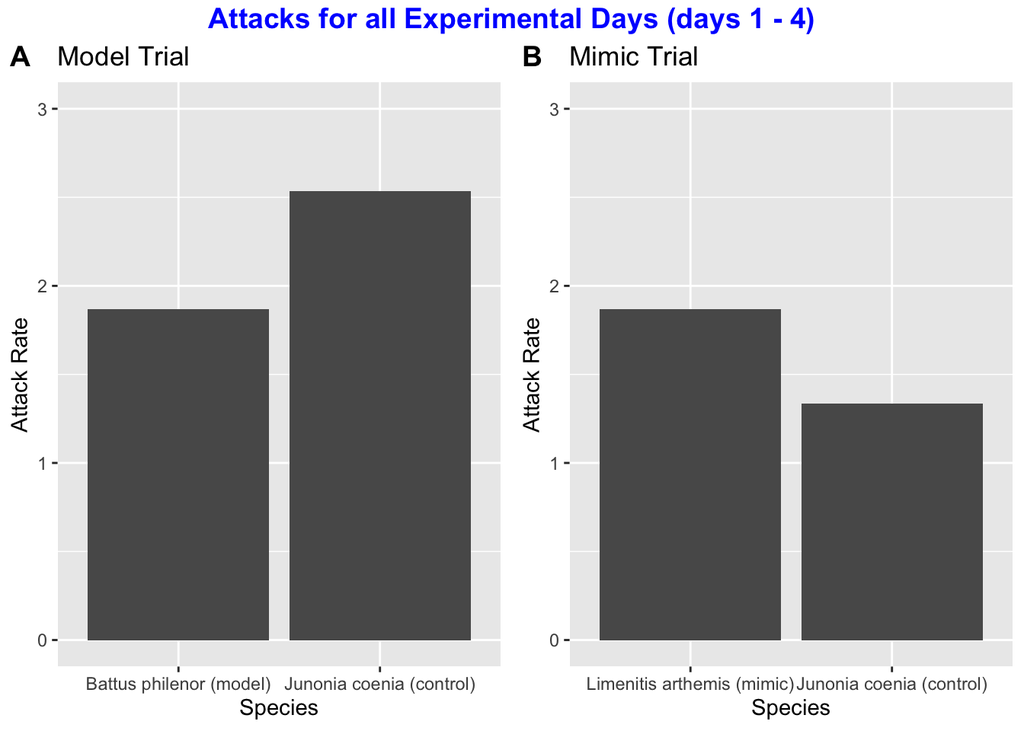

```r
models1 <- ggplot(all.models, aes(x=Group.1, y=percent)) +  geom_bar(stat = "identity") + ylim(0,3)
models1 <- models1  + xlab("Species") + ylab("Attack Rate") + ggtitle("Model Trial")
models1 <- models1 + scale_x_discrete(limits =  c("model_battus", "model_junonia"), labels = c("model_battus" = "Battus philenor (model)","model_junonia" = "Junonia coenia (control)") )
#R will usually automatically sort variables alphabetically, so the "limits" command here allows you to override that and manually specify the order of variables in the ggplot.


mimics1 <- ggplot(all.mimics, aes(x=Group.1, y=percent)) +  geom_bar(stat = "identity") + ylim(0,3)
mimics1 <- mimics1 + xlab("Species") + ylab("Attack Rate") + ggtitle("Mimic Trial")
mimics1 <- mimics1 + scale_x_discrete(limits =  c("mimic_limenitis", "mimic_junonia"), labels = c("mimic_limenitis" = "Limenitis arthemis (mimic)","mimic_junonia" = "Junonia coenia (control)") )

figure <- ggarrange(models1, mimics1,
                    labels = c("A", "B"),
                    ncol = 2, nrow = 1)
all.figure <- annotate_figure(figure, top = text_grob("Attacks for all Experimental Days (days 1 - 4)",
               color = "blue", face = "bold", size = 14))
all.figure
```

figure for post learning days

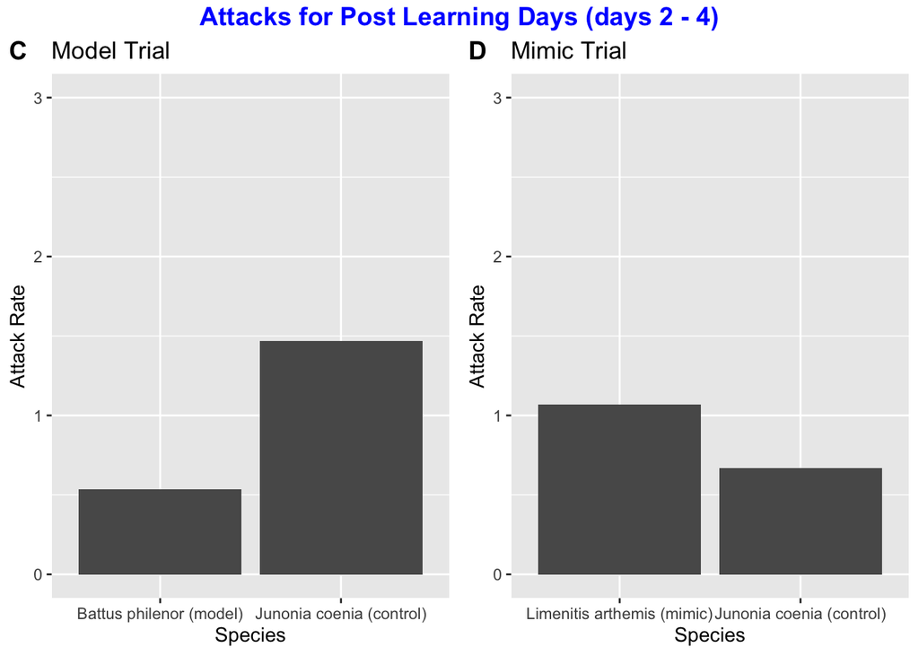

```r
models2 <- ggplot(pld.models, aes(x=Group.1, y=percent)) +  geom_bar(stat = "identity") + ylim(0,3)
models2 <- models2  + xlab("Species") + ylab("Attack Rate") + ggtitle("Model Trial")
models2 <- models2 + scale_x_discrete(limits =  c("model_battus", "model_junonia"), labels = c("model_battus" = "Battus philenor (model)","model_junonia" = "Junonia coenia (control)") )
#R will usually automatically sort variables alphabetically, so the "limits" command here allows you to override that and manually specify the order of variables in the ggplot.


mimics2 <- ggplot(pld.mimics, aes(x=Group.1, y=percent)) +  geom_bar(stat = "identity") + ylim(0,3)
mimics2 <- mimics2 + xlab("Species") + ylab("Attack Rate") + ggtitle("Mimic Trial")
mimics2 <- mimics2 + scale_x_discrete(limits =  c("mimic_limenitis", "mimic_junonia"), labels = c("mimic_limenitis" = "Limenitis arthemis (mimic)","mimic_junonia" = "Junonia coenia (control)") )

figure2 <- ggarrange(models2, mimics2,
                    labels = c("C", "D"),
                    ncol = 2, nrow = 1)
pld.figure <- annotate_figure(figure2, top = text_grob("Attacks for Post Learning Days (days 2 - 4)",  color = "blue", face = "bold", size = 14))
pld.figure
```

combined figure

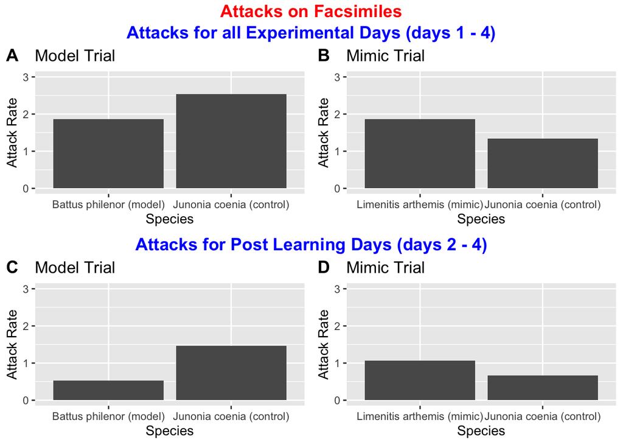

```r
final.fig <- ggarrange(all.figure, pld.figure,
                    ncol = 1, nrow = 2)
final.fig <- annotate_figure(final.fig, top = text_grob("Attacks on Facsimiles",  color = "red", face = "bold", size = 14))
final.fig
```

##Generalized Linear Mixed Model Analysis

```r
m7 <- glmer(attacks ~ species + (1|site/fac.no), data =  temp.delay, family = binomial)
```

```
## boundary (singular) fit: see ?isSingular
```

```r
emmeans(m7, pairwise ~ species)
```

```
## $emmeans
##  species         emmean    SE  df asymp.LCL asymp.UCL
##  mimic_junonia    -12.4 0.796 Inf     -14.0     -10.9
##  mimic_limenitis  -12.1 0.786 Inf     -13.6     -10.5
##  model_battus     -12.1 0.785 Inf     -13.6     -10.5
##  model_junonia    -11.7 0.778 Inf     -13.2     -10.2
##
## Results are given on the logit (not the response) scale.
## Confidence level used: 0.95
##
## $contrasts
##  contrast                         estimate    SE  df z.ratio p.value
##  mimic_junonia - mimic_limenitis -3.74e-01 0.308 Inf  -1.216  0.6165
##  mimic_junonia - model_battus    -3.74e-01 0.308 Inf  -1.216  0.6165
##  mimic_junonia - model_junonia   -7.28e-01 0.293 Inf  -2.488  0.0617
##  mimic_limenitis - model_battus   7.90e-06 0.285 Inf   0.000  1.0000
##  mimic_limenitis - model_junonia -3.54e-01 0.268 Inf  -1.321  0.5496
##  model_battus - model_junonia    -3.54e-01 0.268 Inf  -1.321  0.5496
##
## Results are given on the log odds ratio (not the response) scale.
## P value adjustment: tukey method for comparing a family of 4 estimates
```

we expected high attack rates on battus on day one because predators have not yet learned to avoid this species, so a biologically meaningful analysis would be to look only at “post learning days” by excluding data from day one of the model trials. When we do this, we see a significant difference in attack rates between battus and junonia during the model trials (p=0.0441)

```r
pld <- subset(temp.delay, day %in% c("2", "3", "4"), drop = FALSE)
```

```r
m8 <- glmer(attacks ~ species + (1|site/fac.no), data =  pld, family = binomial)
```

```
## boundary (singular) fit: see ?isSingular
```

```r
emmeans(m8, pairwise ~ species)
```

```
## $emmeans
##  species         emmean    SE  df asymp.LCL asymp.UCL
##  mimic_junonia    -12.5 0.954 Inf     -14.4    -10.64
##  mimic_limenitis  -12.0 0.932 Inf     -13.8    -10.16
##  model_battus     -12.8 0.969 Inf     -14.6    -10.85
##  model_junonia    -11.6 0.920 Inf     -13.4     -9.81
##
## Results are given on the logit (not the response) scale.
## Confidence level used: 0.95
##
## $contrasts
##  contrast                        estimate    SE  df z.ratio p.value
##  mimic_junonia - mimic_limenitis   -0.522 0.424 Inf  -1.233  0.6058
##  mimic_junonia - model_battus       0.240 0.492 Inf   0.489  0.9616
##  mimic_junonia - model_junonia     -0.894 0.404 Inf  -2.215  0.1192
##  mimic_limenitis - model_battus     0.763 0.452 Inf   1.686  0.3312
##  mimic_limenitis - model_junonia   -0.372 0.354 Inf  -1.048  0.7209
##  model_battus - model_junonia      -1.134 0.434 Inf  -2.616  0.0441
##
## Results are given on the log odds ratio (not the response) scale.
## P value adjustment: tukey method for comparing a family of 4 estimates
```

Proportions test to directly compare the proportion of attacks on models and mimics relative to their controls

```r
all <- prop.test(x = c(28, 28), n = c(66, 48))
all
```

```
##
##  2-sample test for equality of proportions with continuity correction
##
## data:  c(28, 28) out of c(66, 48)
## X-squared = 2.2137, df = 1, p-value = 0.1368
## alternative hypothesis: two.sided
## 95 percent confidence interval:
##  -0.36057384  0.04239203
## sample estimates:
##    prop 1    prop 2
## 0.4242424 0.5833333
```

```r
#### Model trial: 28 attacks on Battus, 66 attacks total
#### Mimic trial: 28 attacks on Limenitis, 48 attacks total
```

```r
pld <- prop.test(x = c(8, 16), n = c(30, 26))
pld
```

```
##
##  2-sample test for equality of proportions with continuity correction
##
## data:  c(8, 16) out of c(30, 26)
## X-squared = 5.5656, df = 1, p-value = 0.01832
## alternative hypothesis: two.sided
## 95 percent confidence interval:
##  -0.62958612 -0.06784978
## sample estimates:
##    prop 1    prop 2
## 0.2666667 0.6153846
```

```r
#### In Model trial days 2-4: 8 attacks on Battus, 30 attacks total
### In Mimic trial days 2-4: 16 attacks on Limenitis, 26 attacks total
```

##Compare attacks across the time delayed experiments

```r
models <- subset(temp.delay, trial == "model", drop = FALSE)
mimics <- subset(temp.delay, trial == "mimic", drop = FALSE)
```

```r
m9 <- glmer(attacks ~ species*time.delay + (1|site/fac.no), data =  models, family = binomial)
emmeans(m9, pairwise ~ species*time.delay)
```

```
## $emmeans
##  species       time.delay emmean    SE  df asymp.LCL asymp.UCL
##  model_battus  four        -11.6 0.898 Inf     -13.3     -9.80
##  model_junonia four        -11.0 0.872 Inf     -12.7     -9.27
##  model_battus  one         -12.0 0.926 Inf     -13.8    -10.16
##  model_junonia one         -11.4 0.893 Inf     -13.2     -9.69
##  model_battus  two         -11.4 0.893 Inf     -13.2     -9.69
##  model_junonia two         -11.4 0.893 Inf     -13.2     -9.69
##
## Results are given on the logit (not the response) scale.
## Confidence level used: 0.95
##
## $contrasts
##  contrast                                 estimate    SE  df z.ratio p.value
##  model_battus four - model_junonia four  -5.80e-01 0.446 Inf  -1.302  0.7842
##  model_battus four - model_battus one     4.11e-01 0.527 Inf   0.780  0.9710
##  model_battus four - model_junonia one   -1.14e-01 0.477 Inf  -0.238  0.9999
##  model_battus four - model_battus two    -1.14e-01 0.476 Inf  -0.239  0.9999
##  model_battus four - model_junonia two   -1.14e-01 0.476 Inf  -0.238  0.9999
##  model_junonia four - model_battus one    9.91e-01 0.492 Inf   2.014  0.3342
##  model_junonia four - model_junonia one   4.67e-01 0.436 Inf   1.070  0.8932
##  model_junonia four - model_battus two    4.67e-01 0.436 Inf   1.070  0.8934
##  model_junonia four - model_junonia two   4.67e-01 0.436 Inf   1.070  0.8933
##  model_battus one  - model_junonia one   -5.25e-01 0.519 Inf  -1.010  0.9147
##  model_battus one  - model_battus two    -5.25e-01 0.520 Inf  -1.010  0.9149
##  model_battus one  - model_junonia two   -5.25e-01 0.520 Inf  -1.010  0.9149
##  model_junonia one  - model_battus two   -1.30e-06 0.467 Inf   0.000  1.0000
##  model_junonia one  - model_junonia two   1.00e-06 0.467 Inf   0.000  1.0000
##  model_battus two - model_junonia two     2.30e-06 0.467 Inf   0.000  1.0000
##
## Results are given on the log odds ratio (not the response) scale.
## P value adjustment: tukey method for comparing a family of 6 estimates
```

```r
#### No significant differences in how birds respond to battus and junonia facsimiles between time-delayed trials (consistent with expectations)
```

```r
m10 <- glmer(attacks ~ species*time.delay + (1|site/fac.no), data =  mimics, family = binomial)
emmeans(m10, pairwise ~ species*time.delay)
```

```
## $emmeans
##  species         time.delay emmean    SE  df asymp.LCL asymp.UCL
##  mimic_junonia   four        -11.6 0.977 Inf     -13.6     -9.73
##  mimic_limenitis four        -11.1 0.943 Inf     -13.0     -9.26
##  mimic_junonia   one         -11.6 0.976 Inf     -13.6     -9.73
##  mimic_limenitis one         -11.6 0.976 Inf     -13.6     -9.73
##  mimic_junonia   two         -11.8 0.990 Inf     -13.8     -9.88
##  mimic_limenitis two         -11.2 0.949 Inf     -13.1     -9.37
##
## Results are given on the logit (not the response) scale.
## Confidence level used: 0.95
##
## $contrasts
##  contrast                                    estimate    SE  df z.ratio p.value
##  mimic_junonia four - mimic_limenitis four  -5.34e-01 0.525 Inf  -1.017  0.9125
##  mimic_junonia four - mimic_junonia one     -1.85e-05 0.572 Inf   0.000  1.0000
##  mimic_junonia four - mimic_limenitis one    2.00e-05 0.572 Inf   0.000  1.0000
##  mimic_junonia four - mimic_junonia two      1.74e-01 0.592 Inf   0.294  0.9997
##  mimic_junonia four - mimic_limenitis two   -4.18e-01 0.533 Inf  -0.784  0.9703
##  mimic_limenitis four - mimic_junonia one    5.34e-01 0.524 Inf   1.018  0.9122
##  mimic_limenitis four - mimic_limenitis one  5.34e-01 0.524 Inf   1.018  0.9122
##  mimic_limenitis four - mimic_junonia two    7.08e-01 0.547 Inf   1.295  0.7877
##  mimic_limenitis four - mimic_limenitis two  1.16e-01 0.482 Inf   0.240  0.9999
##  mimic_junonia one - mimic_limenitis one     3.84e-05 0.571 Inf   0.000  1.0000
##  mimic_junonia one - mimic_junonia two       1.74e-01 0.592 Inf   0.295  0.9997
##  mimic_junonia one - mimic_limenitis two    -4.18e-01 0.533 Inf  -0.784  0.9703
##  mimic_limenitis one - mimic_junonia two     1.74e-01 0.592 Inf   0.295  0.9997
##  mimic_limenitis one - mimic_limenitis two  -4.18e-01 0.533 Inf  -0.784  0.9703
##  mimic_junonia two - mimic_limenitis two    -5.92e-01 0.555 Inf  -1.067  0.8944
##
## Results are given on the log odds ratio (not the response) scale.
## P value adjustment: tukey method for comparing a family of 6 estimates
```

```r
### No significant differences in how birds respond to limenitis and junonia between time-delayed trials (contrary to expectations)
```

```r
four <- prop.test(x = c(11, 7), n = c(18, 18))

# IN THE FOUR-WEEK GAP TRIAL:
##    11 attacks on Limenitis
##    7 attacks on Junonia
##    18 attacks total

four
```

```
##
##  2-sample test for equality of proportions with continuity correction
##
## data:  c(11, 7) out of c(18, 18)
## X-squared = 1, df = 1, p-value = 0.3173
## alternative hypothesis: two.sided
## 95 percent confidence interval:
##  -0.1518262  0.5962706
## sample estimates:
##    prop 1    prop 2
## 0.6111111 0.3888889
```

```r
two <- prop.test(x = c(10, 6), n = c(16, 16))

# IN THE TWO-WEEK GAP TRIAL:
##    10 attacks on Limenitis
##    6 attacks on Junonia
##    16 attacks total

two
```

```
##
##  2-sample test for equality of proportions with continuity correction
##
## data:  c(10, 6) out of c(16, 16)
## X-squared = 1.125, df = 1, p-value = 0.2888
## alternative hypothesis: two.sided
## 95 percent confidence interval:
##  -0.1479739  0.6479739
## sample estimates:
## prop 1 prop 2
##  0.625  0.375
```

```r
one <- prop.test(x = c(7, 7), n = c(14, 14))

# IN THE ONE-WEEK GAP TRIAL:
##    7 attacks on Limenitis
##    7 attacks on Junonia
##    14 attacks total

one
```

```
##
##  2-sample test for equality of proportions without continuity
##  correction
##
## data:  c(7, 7) out of c(14, 14)
## X-squared = 0, df = 1, p-value = 1
## alternative hypothesis: two.sided
## 95 percent confidence interval:
##  -0.3703984  0.3703984
## sample estimates:
## prop 1 prop 2
##    0.5    0.5
```

```r
zero <- prop.test(x = c(4, 15), n = c(19, 19))

# IN THE SIMULTANEOUS TRIAL:
##    4 attacks on Limenitis
##    15 attacks on Junonia
##    19 attacks total

zero
```

```
##
##  2-sample test for equality of proportions with continuity correction
##
## data:  c(4, 15) out of c(19, 19)
## X-squared = 10.526, df = 1, p-value = 0.001177
## alternative hypothesis: two.sided
## 95 percent confidence interval:
##  -0.8908227 -0.2670720
## sample estimates:
##    prop 1    prop 2
## 0.2105263 0.7894737
```

##Data Visualization

```r
four_weeks <- subset(mimics, time.delay == "four", drop = FALSE)
two_weeks <- subset(mimics, time.delay == "two", drop = FALSE)
one_week <- subset(mimics, time.delay == "one", drop = FALSE)
sim <- subset(data, trial == "simultaneously", drop = FALSE)

zero_gap <- subset(sim, species %in% c("sim_limenitis", "sim_junonia"), drop = FALSE)
```

```r
four <- aggregate(x= four_weeks$attacks, by= list(four_weeks$species), FUN=sum)
percent <- (four$x/500)*100 ## 500 facsimiles in each time-delay treatment
four$percent <- percent
four
```

```
##           Group.1  x percent
## 1   mimic_junonia  7     1.4
## 2 mimic_limenitis 11     2.2
```

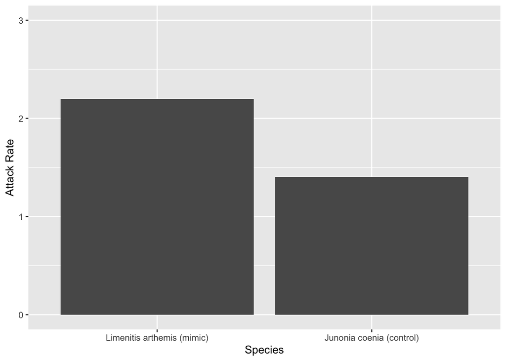

```r
four.fig <- ggplot(four, aes(x=Group.1, y=percent)) +  geom_bar(stat = "identity") + ylim(0,3)
four.fig <- four.fig + xlab("Species") + ylab("Attack Rate")
four.fig <- four.fig + scale_x_discrete(limits =  c("mimic_limenitis", "mimic_junonia"), labels = c("mimic_limenitis" = "Limenitis arthemis (mimic)","mimic_junonia" = "Junonia coenia (control)") )
four.fig
```

```r
two <- aggregate(x= two_weeks$attacks, by= list(two_weeks$species), FUN=sum)
percent <- (two$x/500)*100 ## 500 facsimiles in each time-delay treatment
two$percent <- percent
two
```

```
##           Group.1  x percent
## 1   mimic_junonia  6     1.2
## 2 mimic_limenitis 10     2.0
```

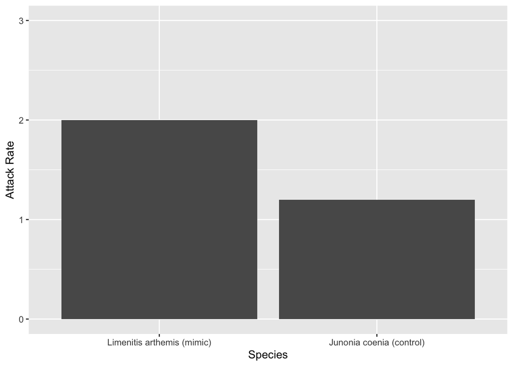

```r
two.fig <- ggplot(two, aes(x=Group.1, y=percent)) +  geom_bar(stat = "identity") + ylim(0,3)
two.fig <- two.fig + xlab("Species") + ylab("Attack Rate")
two.fig <- two.fig + scale_x_discrete(limits =  c("mimic_limenitis", "mimic_junonia"), labels = c("mimic_limenitis" = "Limenitis arthemis (mimic)","mimic_junonia" = "Junonia coenia (control)") )
two.fig
```

```r
one <- aggregate(x= one_week$attacks, by= list(one_week$species), FUN=sum)
percent <- (one$x/500)*100 ## 500 facsimiles in each time-delay treatment
one$percent <- percent
one
```

```
##           Group.1 x percent
## 1   mimic_junonia 7     1.4
## 2 mimic_limenitis 7     1.4
```

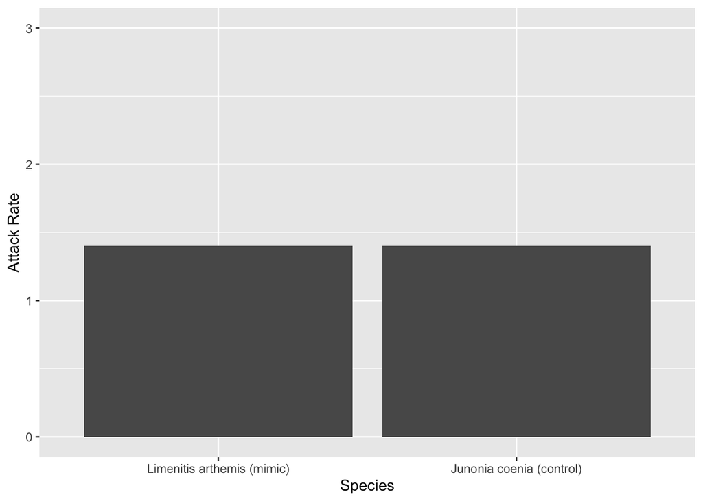

```r
one.fig <- ggplot(one, aes(x=Group.1, y=percent)) +  geom_bar(stat = "identity") + ylim(0,3)
one.fig <- one.fig + xlab("Species") + ylab("Attack Rate")
one.fig <- one.fig + scale_x_discrete(limits =  c("mimic_limenitis", "mimic_junonia"), labels = c("mimic_limenitis" = "Limenitis arthemis (mimic)","mimic_junonia" = "Junonia coenia (control)") )
one.fig
```

```r
zero <- aggregate(x= zero_gap$attacks, by= list(zero_gap$species), FUN=sum)
percent <- (zero$x/500)*100 ## 500 facsimiles in each time-delay treatment
zero$percent <- percent
zero
```

```
##         Group.1  x percent
## 1   sim_junonia 15     3.0
## 2 sim_limenitis  4     0.8
```

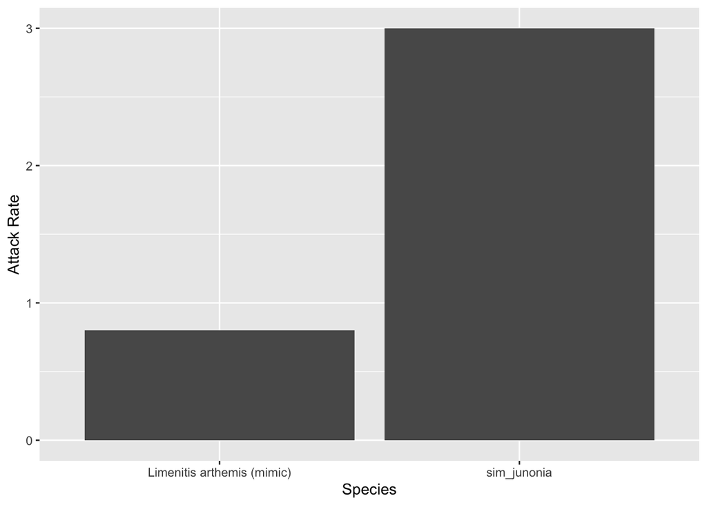

```r
zero.fig <- ggplot(zero, aes(x=Group.1, y=percent)) +  geom_bar(stat = "identity") + ylim(0,3)
zero.fig <- zero.fig + xlab("Species") + ylab("Attack Rate")
zero.fig <- zero.fig + scale_x_discrete(limits =  c("sim_limenitis", "sim_junonia"), labels = c("sim_limenitis" = "Limenitis arthemis (mimic)","simjunonia" = "Junonia coenia (control)") )
zero.fig
```

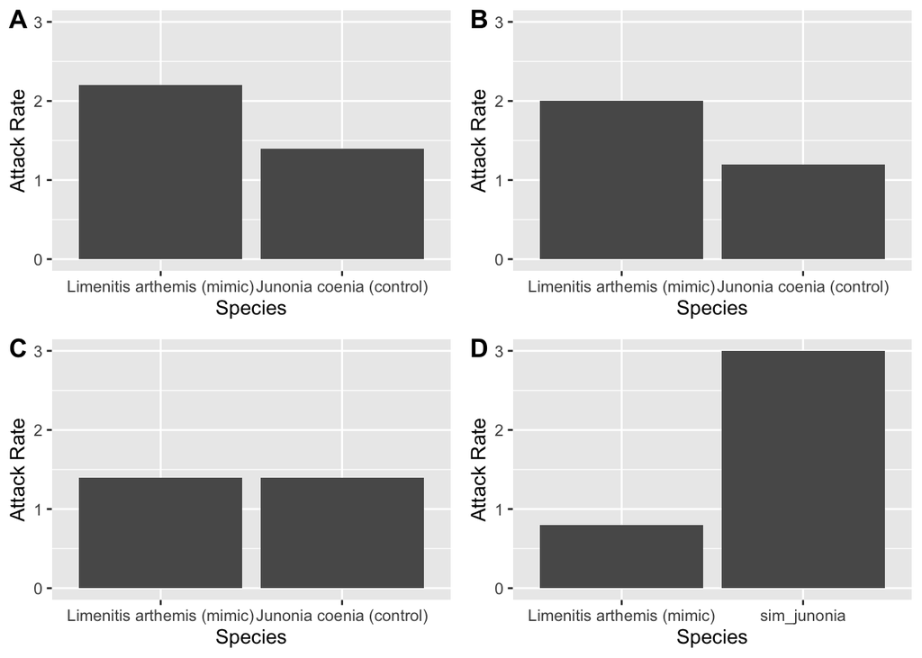

```r
figure <- ggarrange(four.fig, two.fig, one.fig, zero.fig,
                    labels = c("A", "B", "C", "D"),
                    ncol = 2, nrow = 2)
figure
```

QUESTION: -is there a more sophisticated way to directly compare attack rates on models and mimics relative to their controls to control for sample size issues? -comparing differences in attack rates between time-delayed trials is hard because the sample sizes are so low & the GLMMs don’t really work… what can I do ? is the proportions analysis sufficient?